# Multiple Linear Regression: A Macro-Augmented Factor Model of Micron’s Daily Returns

Author

Jan Zika

Published

June 25, 2026

## Research Question

**Which broad market, style, sector, and macroeconomic forces move Micron’s daily stock return, and how much of that return do they jointly explain?**

Micron Technology (MU) is the leading U.S. maker of memory chips — the DRAM and NAND that go into everything from data-center accelerators to phones — and its moves are watched closely as a read on the memory cycle and on demand for AI-driven computing. This analysis asks how much of Micron’s daily return is *systematic* — driven by forces that move the whole market — versus *idiosyncratic* — specific to the company itself. The answer matters to anyone holding or hedging the stock: it tells them what Micron is really exposed to, and how much of its risk could in principle be diversified or hedged away.

The outcome is Micron’s daily **excess return** (its return above the risk-free rate). The seven predictors span the market itself, two investment *style* factors (size and value), a *sector* factor, and three *macroeconomic* signals (the yield-curve slope, the corporate credit spread, and market-wide volatility).

## Dataset and Variables

**Source.** All data is pulled programmatically through public market-data APIs. Daily adjusted closing prices come from a market-price API; the macroeconomic and interest-rate series come from the U.S. Federal Reserve’s FRED API. A small R pipeline (`R/update_data.R`) fetches every series, caches it, and assembles the clean daily panel used here.

**What each row represents.** One **trading day**. Each row pairs Micron’s return for that day with the value of every market, style, sector, and macro factor on the same day.

**Number of observations.** The model is estimated on **1778 trading days**, spanning **2019-01-03** to **2026-06-23**.

**Variables.**

| Role | Variable | What it represents |
| --- | --- | --- |
| Outcome | **MU excess return** | Micron’s daily return minus the risk-free rate. |
| Predictor 1 | **Market** | The total stock market’s excess return (a broad-market ETF minus the risk-free rate). This is the classic CAPM market factor. |
| Predictor 2 | **Size** | Small-cap return minus large-cap return. Positive when smaller companies outperform. |
| Predictor 3 | **Value** | Value-stock return minus growth-stock return. Positive when cheap “value” stocks beat fast-growing “growth” stocks. |
| Predictor 4 | **Sector** | The semiconductor sector’s return above the market. Captures chip-industry-specific moves. |
| Predictor 5 | **TermSpread** | The daily change in the 10-year-minus-3-month Treasury yield slope. A rising slope often signals improving growth expectations. |
| Predictor 6 | **CreditSpread** | The daily change in the Baa-corporate-minus-10-year-Treasury yield spread. A rising spread signals growing financial stress. |
| Predictor 7 | **Volatility** | The daily change in the VIX, the market’s “fear gauge.” |

The risk-free rate is the 3-month Treasury bill rate. The spreads and the VIX enter as **daily changes** rather than levels, so each predictor is a stationary daily signal that lines up naturally with a daily return.

## The Regression Model Equation

The general form of a multiple linear regression with seven predictors is:

$$Y = \beta_0 + \beta_1 X_1 + \beta_2 X_2 + \beta_3 X_3 + \beta_4 X_4
+ \beta_5 X_5 + \beta_6 X_6 + \beta_7 X_7 + \varepsilon$$

where $Y$ is the outcome, $\beta_0$ is the intercept, each $\beta_k$ is the coefficient on predictor $X_k$, and $\varepsilon$ is the error term. Written with our own variable names:

$$\begin{aligned}
\text{MU excess} = {} & \beta_0 + \beta_1\,\text{Market} + \beta_2\,\text{Size}
+ \beta_3\,\text{Value} + \beta_4\,\text{Sector} \\
& + \beta_5\,\text{TermSpread} + \beta_6\,\text{CreditSpread}
+ \beta_7\,\text{Volatility} + \varepsilon
\end{aligned}$$

After fitting the model, the estimated equation (using the actual coefficients computed below) is:

$$\begin{aligned}
\widehat{\text{MU excess}} = {} & 0.0006
+ 1.0776\,\text{Market}
-0.3447\,\text{Size}
+ 0.2347\,\text{Value}
+ 1.0582\,\text{Sector} \\
& + 0.0197\,\text{TermSpread}
-0.0200\,\text{CreditSpread}
-0.0002\,\text{Volatility}
\end{aligned}$$

## Running the Model in R

```r
model <- lm(MU_excess ~ Market + Size + Value + Sector +
              TermSpread + CreditSpread + Volatility, data = model_df)
summary(model)
```

```
Call:
lm(formula = MU_excess ~ Market + Size + Value + Sector + TermSpread +
    CreditSpread + Volatility, data = model_df)

Residuals:
      Min        1Q    Median        3Q       Max
-0.153327 -0.012172 -0.001168  0.010227  0.118116

Coefficients:
               Estimate Std. Error t value Pr(>|t|)
(Intercept)   0.0006141  0.0005128   1.197   0.2313
Market        1.0775963  0.0717760  15.013  < 2e-16 ***
Size         -0.3446753  0.0793703  -4.343 1.49e-05 ***
Value         0.2347163  0.0750802   3.126   0.0018 **
Sector        1.0581909  0.0414379  25.537  < 2e-16 ***
TermSpread    0.0196632  0.0092936   2.116   0.0345 *
CreditSpread -0.0199706  0.0166498  -1.199   0.2305
Volatility   -0.0002207  0.0003923  -0.563   0.5738
---
Signif. codes:  0 '***' 0.001 '**' 0.01 '*' 0.05 '.' 0.1 ' ' 1

Residual standard error: 0.02155 on 1770 degrees of freedom
Multiple R-squared:  0.5748,    Adjusted R-squared:  0.5731
F-statistic: 341.8 on 7 and 1770 DF,  p-value: < 2.2e-16
```

```r
broom::tidy(model) |>
  mutate(across(where(is.numeric), \(x) round(x, 5))) |>
  kable(caption = "Estimated coefficients, standard errors, t-statistics, and p-values.")
```

Estimated coefficients, standard errors, t-statistics, and p-values.

| term | estimate | std.error | statistic | p.value |
| --- | --- | --- | --- | --- |
| (Intercept) | 0.00061 | 0.00051 | 1.19749 | 0.23128 |
| Market | 1.07760 | 0.07178 | 15.01333 | 0.00000 |
| Size | -0.34468 | 0.07937 | -4.34262 | 0.00001 |
| Value | 0.23472 | 0.07508 | 3.12621 | 0.00180 |
| Sector | 1.05819 | 0.04144 | 25.53678 | 0.00000 |
| TermSpread | 0.01966 | 0.00929 | 2.11578 | 0.03450 |
| CreditSpread | -0.01997 | 0.01665 | -1.19945 | 0.23051 |
| Volatility | -0.00022 | 0.00039 | -0.56256 | 0.57381 |

## Interpreting the Model Summary

### A. Coefficients

Each coefficient is the average change in Micron’s daily excess return associated with a one-unit increase in that predictor, **holding the other six predictors constant**.

### B. P-values

```r
broom::tidy(model) |>
  transmute(term, estimate = round(estimate, 5), p.value = signif(p.value, 3),
            significant_5pct = ifelse(p.value < 0.05, "yes", "no")) |>
  kable(caption = "Which predictors show statistically significant relationships.")
```

Which predictors show statistically significant relationships.

| term | estimate | p.value | significant_5pct |
| --- | --- | --- | --- |
| (Intercept) | 0.00061 | 2.31e-01 | no |
| Market | 1.07760 | 0.00e+00 | yes |
| Size | -0.34468 | 1.49e-05 | yes |
| Value | 0.23472 | 1.80e-03 | yes |
| Sector | 1.05819 | 0.00e+00 | yes |
| TermSpread | 0.01966 | 3.45e-02 | yes |
| CreditSpread | -0.01997 | 2.31e-01 | no |
| Volatility | -0.00022 | 5.74e-01 | no |

A small p-value is evidence that a predictor’s true coefficient is different from zero. The **market, size, value, sector, and term-spread** factors are all significant at the 5% level: the data give strong evidence that each is genuinely related to Micron’s return, and the **sector** and **market** loadings in particular are estimated with overwhelming confidence. By contrast, the **credit spread** and the **change in the VIX** are *not* statistically significant for Micron: once the market and sector factors are present, these two add no detectable independent relationship with Micron’s daily return. A non-significant predictor does not prove there is no relationship — only that this data set shows no clear evidence of one.

The **intercept** is likewise not significant, which is the desired result for an excess-return model: it indicates Micron earns no reliable daily return beyond what its factor exposures explain — no “free lunch” left unaccounted for by the model.

### C. R-squared

The R-squared value is **0.575**, which means the model explains approximately **57%** of the day-to-day variation in Micron’s excess return. In other words, roughly that share of Micron’s daily moves is *systematic* — traceable to broad market, style, sector, and macro forces — while the remaining **43%** is **idiosyncratic**: specific to Micron (memory-pricing news, earnings, guidance, supply decisions) and not captured by these factors.

### D. Adjusted R-squared

The adjusted R-squared is **0.573**. Adjusted R-squared penalizes the model for each additional predictor, so it rises only when a new variable adds explanatory power beyond what its degrees of freedom cost. Here it is almost identical to the ordinary R-squared (0.575), indicating that the predictor count is not inflating the fit. This is a statement about the set of predictors as a whole, not about each one individually: with 1778 observations, one predictor costs a negligible fraction of a degree of freedom, so a flat adjusted R-squared is consistent with two of the seven predictors — the credit spread and the change in the VIX — being statistically insignificant. The overall fit is not an artifact of model size, but not every predictor contributes detectable independent explanatory power.

## Residual Errors and Model Fit

A **residual** is the difference between the actual value and the model’s prediction:

$$\text{Residual} = \text{Actual} - \text{Predicted}$$

A residual tells us how far off the model was on a single day. A **positive** residual means the model **underpredicted** (Micron did better than expected); a **negative** residual means it **overpredicted** (Micron did worse than expected). For example, if Micron’s actual excess return on a day was 3% and the model predicted 2%, the residual is +1%.

## Residual Plot

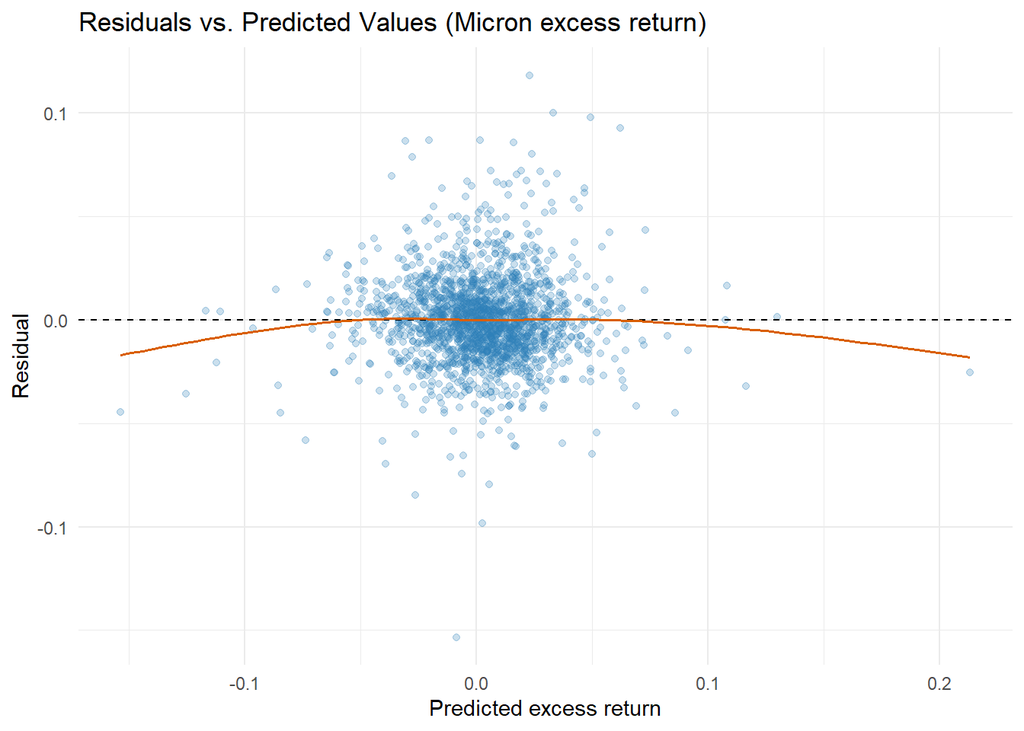

Residuals versus fitted values. A random horizontal band around zero indicates a well-behaved linear model.

```r
model_df$predicted <- fitted(model)
model_df$residuals <- residuals(model)

ggplot(model_df, aes(x = predicted, y = residuals)) +
  geom_point(alpha = 0.25, color = "#2c7fb8") +
  geom_hline(yintercept = 0, linetype = "dashed") +
  geom_smooth(se = FALSE, color = "#d95f02", linewidth = 0.7) +
  labs(title = "Residuals vs. Predicted Values (Micron excess return)",
       x = "Predicted excess return", y = "Residual") +
  theme_minimal()
```

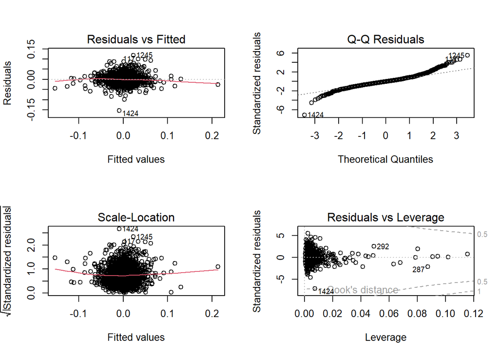

Standard regression diagnostics: residuals vs fitted, Normal Q-Q, scale-location, and residuals vs leverage.

```r
par(mfrow = c(2, 2)); plot(model); par(mfrow = c(1, 1))
```

The residuals are scattered fairly evenly above and below zero with no obvious trend across the range of predictions, so the orange smoother stays close to the dashed zero line — the **linearity** assumption looks reasonable. The visible feature is that the *spread* of the residuals widens on high-volatility days: large surprises cluster together, a familiar property of stock returns and an especially pronounced one for a cyclical memory name whose earnings days produce outsized moves. The model does not systematically over- or under-predict in any region; its errors are roughly centered on zero everywhere, but it is least precise during turbulent market periods. The Q-Q plot shows heavier tails than a normal distribution — extreme days (large jumps) happen more often than a bell curve would predict.

```r
vif_vals <- car::vif(model)
bp <- lmtest::bptest(model)
dw_lag1 <- cor(head(residuals(model), -1), tail(residuals(model), -1))
```

## Has the AI Era Changed Micron’s Character?

The model above estimates a single set of factor loadings over the entire sample, which is valid only if those loadings are stable through time. Micron is a memory producer, and large-scale AI computing — a major new source of demand for high-bandwidth memory (HBM) — is a plausible reason for its loadings to have shifted. If they did, a full-sample regression reports an average across two distinct regimes and fits each one less well than a regime-specific model would. This section tests loading stability, locates any break date from the data, and quantifies what changed.

### An AI-demand factor

Exposure to AI computing demand enters as a daily signal through NVIDIA’s return, which serves as a bellwether for data-center AI spending — the same spending that drives HBM demand at Micron. Much of NVIDIA’s daily move is already captured by the market and semiconductor factors, so the raw return would be collinear with them. The **AI** factor is therefore the residual of NVIDIA’s return after regressing it on the market and sector factors: the orthogonal component that those two factors do not explain. This isolates the incremental AI-demand signal and keeps it distinct from the existing predictors.

### Detecting the break

The break date is estimated from the data rather than fixed in advance, since choosing it by inspection would bias any test evaluated at that point. The **supF (Quandt–Andrews) test** computes a Chow break statistic at every candidate date in the interior of the sample, takes the maximum, and compares it against a critical value adjusted for having searched over all dates. It tests the null of stable coefficients against a single unknown break and, if rejected, identifies the most likely break date.

```r
fs   <- strucchange::Fstats(ai_form, data = brk_df, from = 0.15)
supf <- strucchange::sctest(fs)
brk_date <- brk_df$date[fs$breakpoint]

bp_obj <- strucchange::breakpoints(ai_form, data = brk_df, h = 0.15)
n_breaks <- sum(!is.na(bp_obj$breakpoints))
```

### Why that date

The estimated break falls in **March 2024**, the quarter in which Micron’s guidance shifted to HBM capacity selling out and AI data-center demand as the primary driver of its business. This coincides with the market’s re-rating of Micron from a cyclical commodity-memory producer toward an AI-memory name. The break therefore corresponds to a datable change in the company’s business rather than a purely statistical artifact. The chart below shows Micron’s rolling factor loadings over the sample, with relevant AI milestones marked.

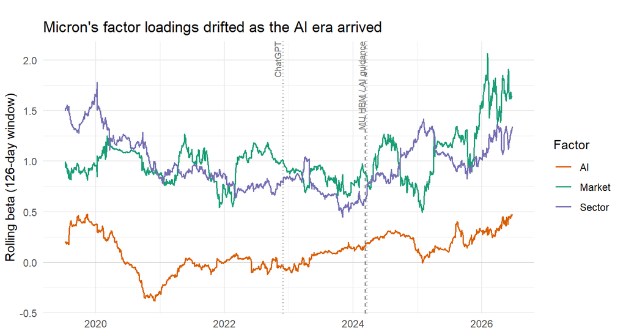

Rolling 126-trading-day factor loadings for Micron. Vertical lines mark AI milestones; the dashed line is the statistically detected break.

```r
win <- 126L
roll_betas <- function(i) {
  idx <- (i - win + 1):i
  cf <- coef(lm(MU_excess ~ Market + Sector + AI, data = brk_df[idx, ]))
  c(Market = cf["Market"], Sector = cf["Sector"], AI = cf["AI"])
}
roll <- t(vapply(win:nrow(brk_df), roll_betas, numeric(3)))
roll_df <- tibble::tibble(
  date   = brk_df$date[win:nrow(brk_df)],
  Market = roll[, 1], Sector = roll[, 2], AI = roll[, 3]
) |>
  tidyr::pivot_longer(-date, names_to = "Factor", values_to = "Beta")

milestones <- tibble::tibble(
  date  = as.Date(c("2022-11-30", "2024-03-20")),
  label = c("ChatGPT", "MU HBM / AI guidance")
)

ggplot(roll_df, aes(date, Beta, color = Factor)) +
  geom_hline(yintercept = 0, color = "grey80") +
  geom_vline(xintercept = brk_date, linetype = "dashed", color = "grey40") +
  geom_vline(data = milestones, aes(xintercept = date),
             linetype = "dotted", color = "grey55") +
  geom_text(data = milestones, aes(x = date, y = Inf, label = label),
            inherit.aes = FALSE, angle = 90, vjust = -0.3, hjust = 1,
            size = 2.7, color = "grey45") +
  geom_line(linewidth = 0.7) +
  scale_color_manual(values = c(Market = "#1b9e77", Sector = "#7570b3",
                                AI = "#d95f02")) +
  labs(title = "Micron's factor loadings drifted as the AI era arrived",
       x = NULL, y = "Rolling beta (126-day window)") +
  theme_minimal() +
  theme(plot.margin = margin(t = 18, r = 8, b = 4, l = 4))
```

### What changed, and by how much

To quantify the shift, we fit a single model over the full sample with a **Post** indicator (one from the break date onward) interacted with the factors most likely to have moved. Each interaction coefficient is the *change* in that loading after the break. Because the residuals are heteroskedastic, the coefficients are tested with heteroskedasticity-robust (HC1) standard errors.

```r
brk_df$Post <- as.integer(brk_df$date >= brk_date)
inter <- lm(MU_excess ~ (Market + Sector + Value + AI) * Post +
              Size + TermSpread + CreditSpread + Volatility, data = brk_df)

robust_se <- lmtest::coeftest(inter, vcov. = sandwich::vcovHC(inter, type = "HC1"))
broom::tidy(robust_se) |>
  filter(grepl(":Post$", term) | term == "AI") |>
  mutate(across(where(is.numeric), \(x) round(x, 4))) |>
  kable(caption = "Post-break changes in Micron's factor loadings (robust standard errors). A significant interaction means the loading shifted after the AI-era break.")
```

Post-break changes in Micron’s factor loadings (robust standard errors). A significant interaction means the loading shifted after the AI-era break.

| term | estimate | std.error | statistic | p.value |
| --- | --- | --- | --- | --- |
| AI | 0.1005 | 0.0284 | 3.5336 | 0.0004 |
| Market:Post | 0.1732 | 0.1850 | 0.9361 | 0.3493 |
| Sector:Post | 0.1534 | 0.1102 | 1.3918 | 0.1641 |
| Value:Post | -0.3135 | 0.2191 | -1.4306 | 0.1527 |
| AI:Post | 0.1554 | 0.0748 | 2.0777 | 0.0379 |

```r
periods <- lapply(c(0, 1), function(p) {
  d  <- brk_df[brk_df$Post == p, ]
  m  <- lm(base_form, data = d)
  ma <- lm(ai_form,  data = d)
  tibble::tibble(
    Period   = if (p == 0) "Pre-break" else "Post-break",
    N        = nrow(d),
    `Market beta` = round(coef(m)["Market"], 3),
    `Sector beta` = round(coef(m)["Sector"], 3),
    `AI beta`     = round(coef(ma)["AI"], 3),
    `R-squared`   = round(summary(m)$r.squared, 3)
  )
})
ai_pre  <- periods[[1]]$`AI beta`; ai_post <- periods[[2]]$`AI beta`
mkt_pre <- periods[[1]]$`Market beta`; mkt_post <- periods[[2]]$`Market beta`
sec_pre <- periods[[1]]$`Sector beta`; sec_post <- periods[[2]]$`Sector beta`
r2_pre  <- periods[[1]]$`R-squared`;   r2_post  <- periods[[2]]$`R-squared`

# Raw-return volatility and tail-frequency, by regime, to characterize the
# change in how violently Micron trades (annualized from daily returns).
mu_raw <- prices_wide |> arrange(date) |>
  transmute(date, MU = MU / dplyr::lag(MU) - 1) |>
  tidyr::drop_na() |>
  dplyr::semi_join(brk_df, by = "date") |>
  dplyr::mutate(Post = as.integer(date >= brk_date))
vol_pre   <- sd(mu_raw$MU[mu_raw$Post == 0]) * sqrt(252) * 100
vol_post  <- sd(mu_raw$MU[mu_raw$Post == 1]) * sqrt(252) * 100
big_pre   <- mean(abs(mu_raw$MU[mu_raw$Post == 0]) > 0.05) * 100
big_post  <- mean(abs(mu_raw$MU[mu_raw$Post == 1]) > 0.05) * 100

dplyr::bind_rows(periods) |>
  kable(caption = "Micron's factor loadings and fit, estimated separately before and after the detected break.")
```

Micron’s factor loadings and fit, estimated separately before and after the detected break.

| Period | N | Market beta | Sector beta | AI beta | R-squared |
| --- | --- | --- | --- | --- | --- |
| Pre-break | 1236 | 1.054 | 1.02 | 0.105 | 0.642 |
| Post-break | 542 | 1.263 | 1.09 | 0.255 | 0.528 |

Among the interacted loadings, only the **AI-demand factor shows a statistically significant change** at the break. Micron’s loading on the orthogonal AI signal roughly doubles, from 0.10 before the break to 0.26 after, and the change remains significant under heteroskedasticity-robust standard errors. The market and sector loadings also increase, but their shifts are not individually distinguishable from zero once the AI factor is included. The regime change is thus concentrated in Micron’s sensitivity to AI computing demand rather than spread across its broad-market or sector exposures.

The post-break R-squared is lower than the pre-break value. As Micron’s returns became more tied to AI-specific developments, a larger share of its daily variation moved outside the span of the fixed factor set and into the idiosyncratic component. The stock both loaded more heavily on AI demand and became harder to explain with any constant set of factors.

```r
tibble::tibble(
  Period = c("Pre-break", "Post-break"),
  `Annualized volatility` = sprintf("%.0f%%", c(vol_pre, vol_post)),
  `Days with >5% move`    = sprintf("%.1f%%", c(big_pre, big_post))
) |>
  kable(caption = "Raw-return volatility and large-move frequency, before and after the detected break.")
```

Raw-return volatility and large-move frequency, before and after the detected break.

| Period | Annualized volatility | Days with >5% move |
| --- | --- | --- |
| Pre-break | 46% | 7.6% |
| Post-break | 65% | 16.2% |

Taken together, the results give a specific characterization of the regime change: Micron’s factor loadings were not stable across the sample, the instability is dated to March 2024 and aligns with a concrete shift in the company’s business, and its principal manifestation is an approximately doubled sensitivity to AI computing demand. Treating the change this way — as a measurable shift in existing loadings plus one orthogonal demand factor — keeps each component identified and avoids attributing the move to a single undated event.

## The “So What?”

The full-sample model answers the question it was built to answer — over the whole period, the **semiconductor sector** is Micron’s dominant exposure and its market beta sits modestly above one — but those coefficients average across two distinct regimes, and the structural-break analysis shows the average understates what Micron has become. The relevant description of the stock today is the post-2024 regime, not the blended average.

For an investor, the practical implications follow from the current regime, not the historical average. Micron today is close to a leveraged, high-volatility bet on the semiconductor sector and the AI-memory cycle: an investor holding the chip sector already carries much of its systematic risk, but in amplified form, and with sizable AI-sentiment exposure on top. Its risk is no longer that of a “mildly high-beta” name — it is a stock that routinely moves several percent in a day and is repriced sharply on AI-demand news. Three caveats bound the analysis: it measures association, not causation; its errors are largest on the most volatile days; and, most importantly here, its loadings are regime-dependent — the March 2024 break is direct evidence that they can shift again as the AI cycle evolves. Like any factor model, it explains the *systematic* part of Micron’s returns rather than predicting any single day’s move, since a large idiosyncratic share remains by construction. Within that scope it does its job: it identifies which forces drive Micron, quantifies how strongly each one does, shows that those relationships shifted in March 2024, and delivers a clear, current picture of what the stock is exposed to and how violently it now trades.